# An Introduction to `ggplot2`

Once you find a palette you like, you can visualize it as follows:

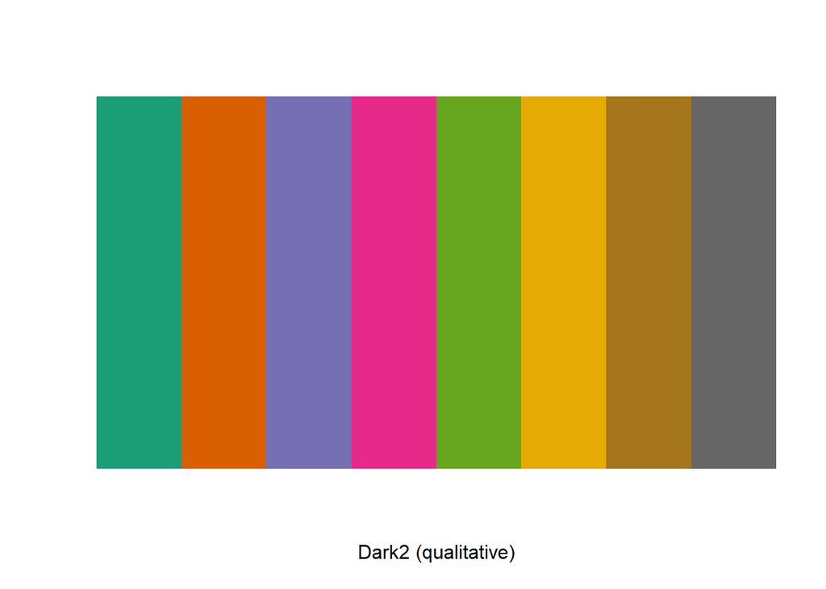

```r
display.brewer.pal(n=8, name="Dark2")
```

Here, the `n` attribute is the number of discrete colors you want in the palette.

Let’s add a palette we dig to our plot:

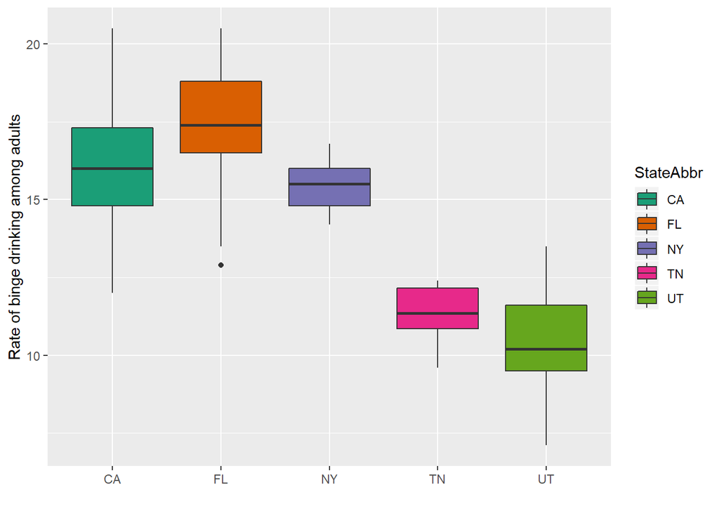

```r
bwplot + scale_fill_brewer(palette = "Dark2")
```

If you’re a big Wes Anderson fan, then try this:

```r
library(wesanderson)
names(wes_palettes)
```

```
##  [1] "BottleRocket1"  "BottleRocket2"  "Rushmore1"      "Rushmore"
##  [5] "Royal1"         "Royal2"         "Zissou1"        "Darjeeling1"
##  [9] "Darjeeling2"    "Chevalier1"     "FantasticFox1"  "Moonrise1"
## [13] "Moonrise2"      "Moonrise3"      "Cavalcanti1"    "GrandBudapest1"
## [17] "GrandBudapest2" "IsleofDogs1"    "IsleofDogs2"
```

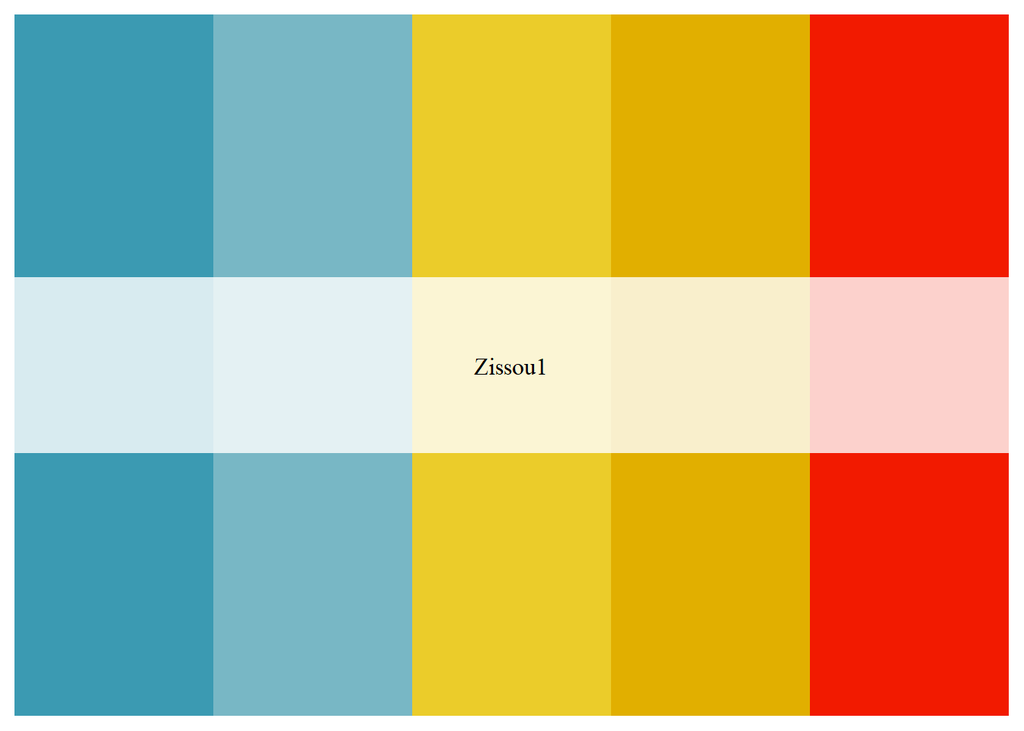

```r
wes_palette("Zissou1")
```

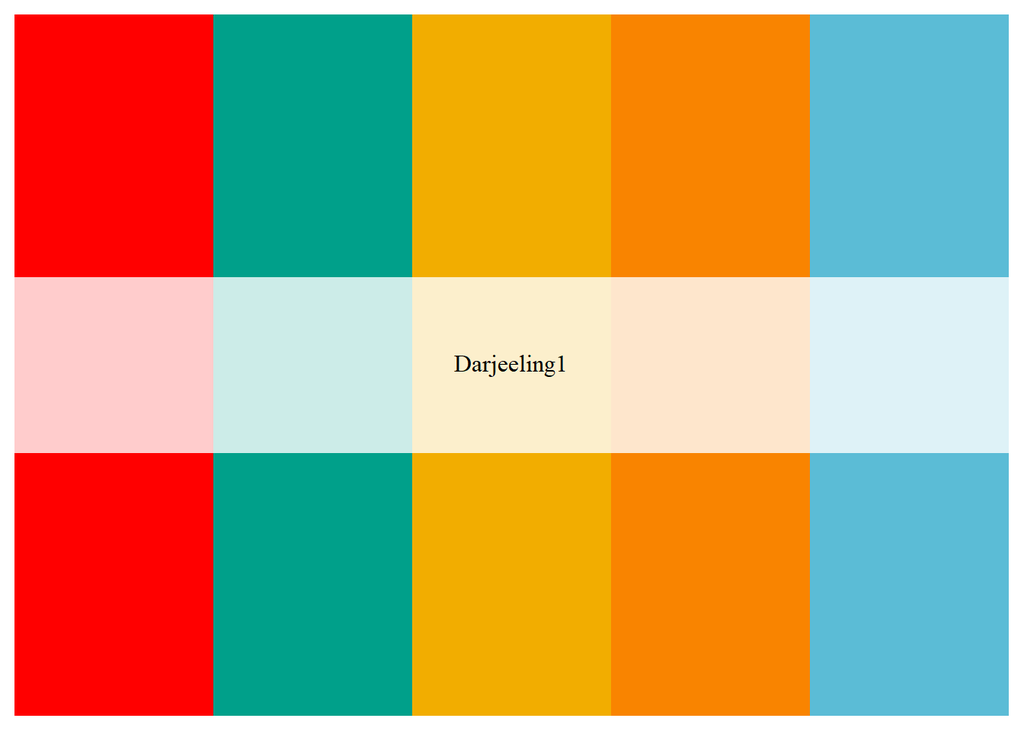

```r
wes_palette("Darjeeling1")
```

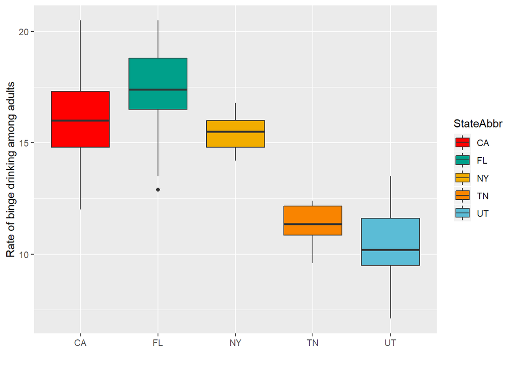

```r
bwplot + scale_fill_manual(values = wes_palette(n=5, name="Darjeeling1"))
```

If you’re a bit more boring and really want a gray-scale plot, that’s easy too:

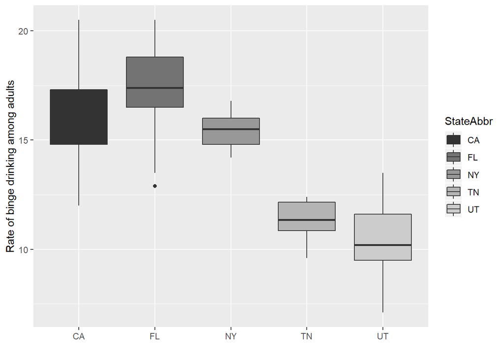

```r
bwplot + scale_fill_grey()
```

## Color blind friendly palettes

In recent years, there has been growing awareness about using palettes that are both color blind friendly and that transfer well to gray-scale (i.e. when converted to black and white).

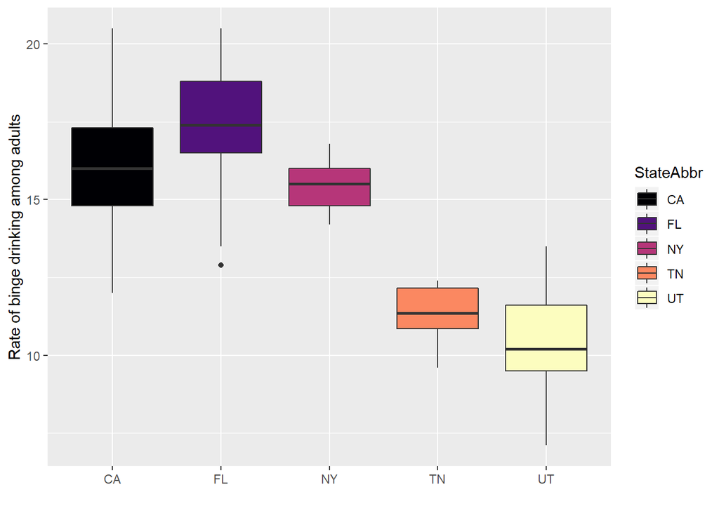

```r
library(viridis)
bwplot + scale_fill_viridis(discrete=T, option="magma")
```

Color options include `magma`, `plasma`, `viridis`, `inferno`, and `cividis`.

The `dichromat` package also contains color schemes suitable to folks who are color blind:

```r
library(dichromat)
names(dichromat::colorschemes)
```

```
##  [1] "BrowntoBlue.10"         "BrowntoBlue.12"
##  [3] "BluetoDarkOrange.12"    "BluetoDarkOrange.18"
##  [5] "DarkRedtoBlue.12"       "DarkRedtoBlue.18"
##  [7] "BluetoGreen.14"         "BluetoGray.8"
##  [9] "BluetoOrangeRed.14"     "BluetoOrange.10"
## [11] "BluetoOrange.12"        "BluetoOrange.8"
## [13] "LightBluetoDarkBlue.10" "LightBluetoDarkBlue.7"
## [15] "Categorical.12"         "GreentoMagenta.16"
## [17] "SteppedSequential.5"
```

## Themes in `ggplot`

Everything you ever wanted to know about themes found [here](http://www.sthda.com/english/wiki/ggplot2-themes-and-background-colors-the-3-elements) but let’s play with a few quickly.

`theme_bw()` remove the gray background:

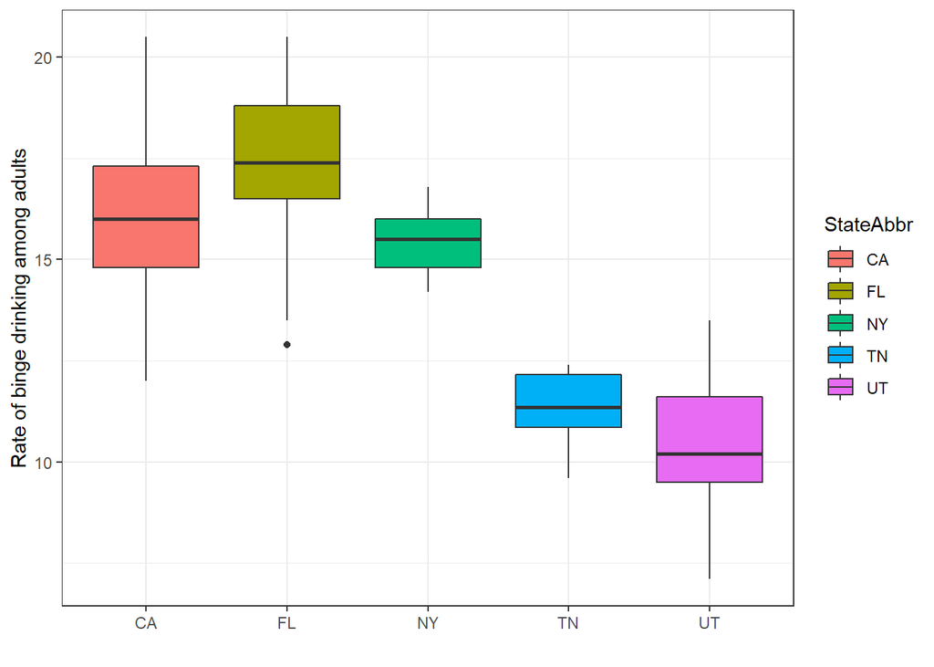

```r
bwplot +
  theme_bw()
```

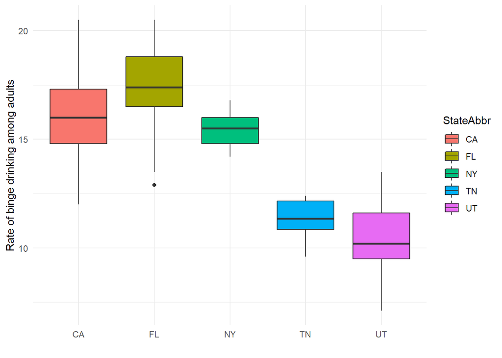

```r
bwplot +
  theme_minimal()
```

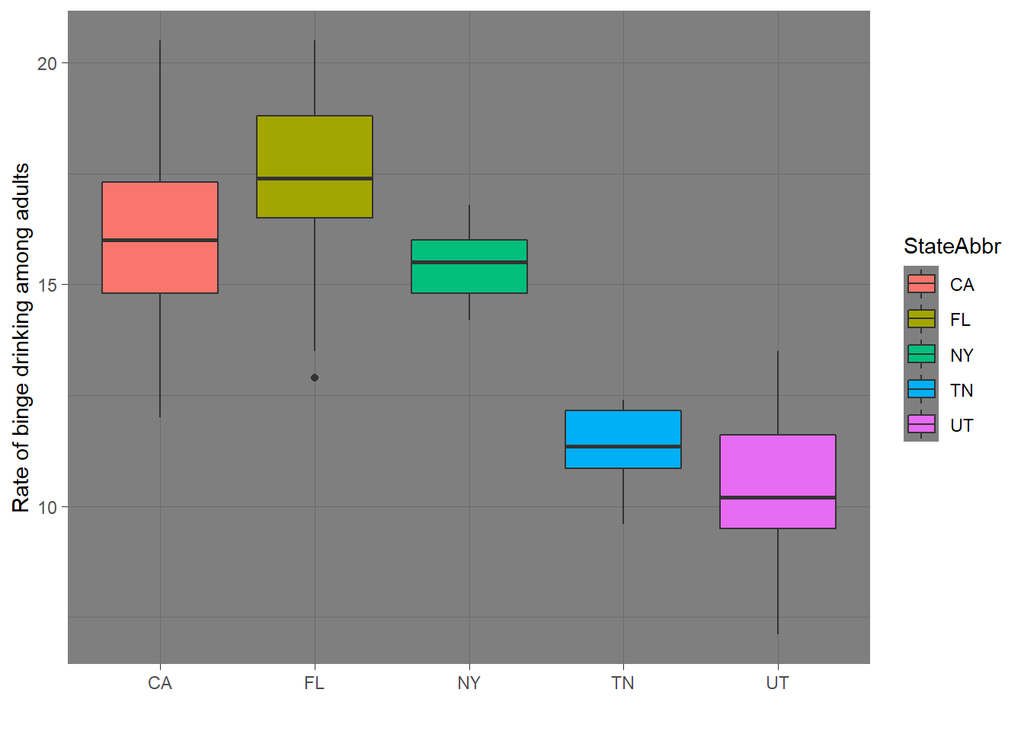

```r
bwplot +
  theme_dark()
```

If you want to go theme-crazy, install the `ggthemes` package:

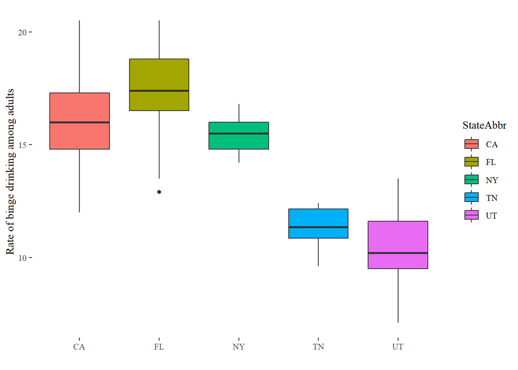

```r
library(ggthemes)
bwplot +
  theme_tufte()
```

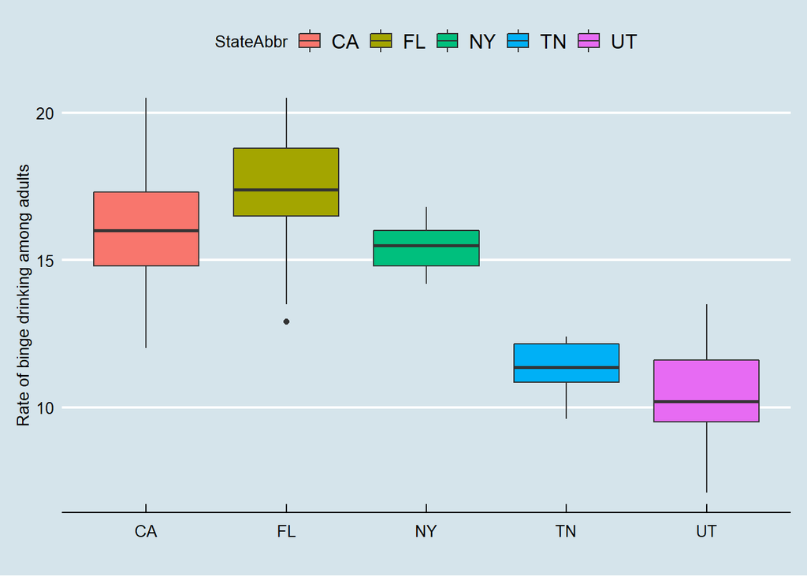

```r
# The Economist
bwplot +
  theme_economist()
```

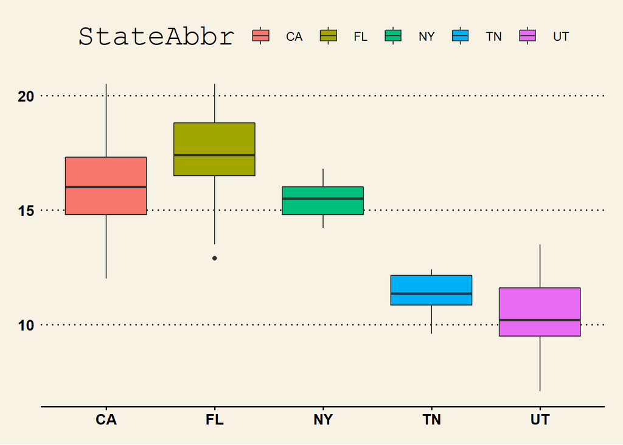

```r
# Wall Street Journal
bwplot +
  theme_wsj()
```

You can see all ggthemes [here](https://yutannihilation.github.io/allYourFigureAreBelongToUs/ggthemes/). You can also explore the many many ways you can amp up your ggplotting skills (animations anyone?) [here](https://www.ggplot2-exts.org/ggiraph.html).

# Our final plot

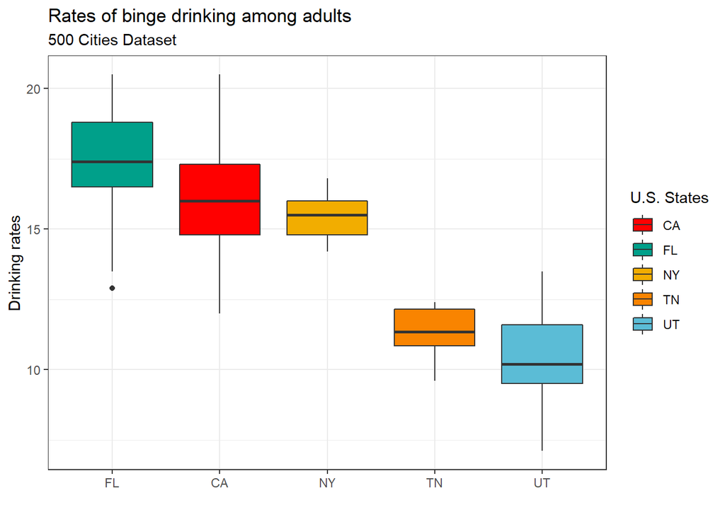

```r
health %>%
  filter(StateAbbr %in% c("UT", "NY", "CA", "TN", "FL")) %>%
  ggplot() +
  geom_boxplot(aes(x = reorder(StateAbbr, desc(BingeDrinking)), y = BingeDrinking, fill = StateAbbr)) +
  labs(title = "Rates of binge drinking among adults", subtitle = "500 Cities Dataset") +
  guides(fill=guide_legend(title="U.S. States")) +
  ylab("Drinking rates") +
  xlab("") +
  scale_fill_manual(values = wes_palette(n=5, name="Darjeeling1")) +
  theme_bw()
```

# Saving your figures

When working with `ggplot2`, save figures using the `ggsave()` function. Note that to use this function, you’ll need to dump your ggplot into a variable:

```r
my_sweet_plot <- ggplot(data = my_data) +
  geom_point(aes(x = YEAR, y = VALUE))

ggsave(my_sweet_plot, "./myfigure.png")
```

You can read more about writing your figures to a other types of files [here](http://stat545.com/block017_write-figure-to-file.html).

# Additional Resources

- More on creative ways to visualize data distributions [here.](https://rafalab.github.io/dsbook/distributions.html)
- [Secrets of a happy graphing life.](http://stat545.com/block016_secrets-happy-graphing.html)
- The [ggplot2 cheatsheet!](https://www.rstudio.com/wp-content/uploads/2015/03/ggplot2-cheatsheet.pdf)
- Chapters 5 - 12 in this [online textbook](https://serialmentor.com/dataviz/visualizing-amounts.html) provide a great overview of when to use different visualization strategies.